# Self-Study: Solution

Tobias Bluhmki

2024-09-02

This document accompanies the simulation study shown in the course. We provide worked examples of an unanchored form of IPTW ($B$ IPD and $C$ IPD) and an anchored form of MAIC ($AB$ IPD and $AC$ aggregated data). For simplicity we included only two covariates, age and gender and age will act as an effect modifier. The aim is to obtain estimates ($log(OR)$ for the comparison $B$ vs. $C$.

We load the following packages:

```r
###Install and load required packages
if(!require(dplyr)) {install.packages("dplyr"); library(dplyr)}
if(!require(tidyr)) {install.packages("tidyr"); library(tidyr)}
if(!require(wakefield)) {install.packages("wakefield"); library(wakefield)}
if(!require(ggplot2)) {install.packages("ggplot2"); library(ggplot2)}
if(!require(sandwich)) {install.packages("sandwich"); library(sandwich)}
if(!require(WeightIt)) {install.packages("WeightIt"); library(WeightIt)}
if(!require(cobalt)) {install.packages("cobalt"); library(cobalt)}
if(!require(MatchIt)) {install.packages("MatchIt"); library(MatchIt)}
if(!require(DescTools)) {install.packages("DescTools"); library(DescTools)}
```

## (Unanchored) Inverse Probability of Treatment Weighting

First, we load the dataset `IPTW_unanchored.csv`.

```r
data.IPTW <- read.csv("IPTW_unanchored.csv")
```

The data looks as follows:

```r
print(data.IPTW[1:6,],row.names=F)
```

```
##  ID age gender trt y
##   1  25 Female   B 0
##   2  61 Female   B 0
##   3  38 Female   B 0
##   4  66   Male   B 1
##   5  25   Male   B 1
##   6  47   Male   B 0
```

| Parameter name | Description |
| --- | --- |
| *ID* | unique subject identifier |
| *age* | age (continuous) |
| *gender* | Sex (female or male) |
| *trt* | Treatment assignment ($B$ or $C$) |
| *y* | Event indicator (1: yes, 0: no) |

### Tabulation of covariates per treatment arm

```r
# Tabulate (via dplyr methods)
data.IPTW %>% group_by(trt) %>%
  summarise(n(), mean(age), sd(age), `n(male)`=sum(gender=="Male"),
            `%(male)`=mean(gender=="Male"), sum(y), mean(y))
```

```
## # A tibble: 2 × 8
##   trt   `n()` `mean(age)` `sd(age)` `n(male)` `%(male)` `sum(y)` `mean(y)`
##   <chr> <int>       <dbl>     <dbl>     <int>     <dbl>    <int>     <dbl>
## 1 B       200        43.0     15.3        144     0.72        66      0.33
## 2 C       300        54.9      8.52       118     0.393       27      0.09
```

We see that age and gender are imbalanced between treatment groups. Thus, these are **confounding factors**.

### Naive treatment comparison

We are now ready to proceed with our analyses. First, we will estimate the unadjusted (naive) indirect comparison. For that purpose, only `trt` will enter the binomial regression model as predictor:

```r
### Univariate Logistic regression (B vs. C) - Use dummy variable to ensure proper comparison
uni.log <- glm(y ~ (trt=="B") , data = data.IPTW, family = binomial)

###compute confidence intervals
ci.uni.log<-confint(uni.log)
```

The naive estimate of the log odds ratio of treatment $B$ vs. $C$ is 1.61 (95% CI: 1.12-2.11)

### Multivariate adjustment

Second, we will estimate the multivariate adjusted indirect comparison. For that purpose, `trt` as well as `age` and `gender` will enter the binomial regression model as predictors:

```r
### Multivariate Logistic regression (B vs. C)
multi.log <- glm(y ~ (trt=="B") + age + gender , data = data.IPTW, family = binomial)

###compute confidence intervals
ci.multi.log<-confint(multi.log)
```

The adjusted estimate of the log odds ratio of treatment $B$ vs. $C$ is 0.65 (95% CI: 0.04-1.26)

### Compute unadjusted weights

```r
### Manually compute Propensity Scores
PS.fit <- glm((trt=="B")~ age+ gender,family="binomial", data=data.IPTW)
data.IPTW$PS <- predict(PS.fit, type="response")

### Compute unstabilized weights
data.IPTW$IPW <- (data.IPTW$trt=="B")/data.IPTW$PS + (1-(data.IPTW$trt=="B"))/(1-data.IPTW$PS)

### Check distribution of unstabilized weights
tapply(data.IPTW$IPW, data.IPTW$trt, summary)
```

```
## $B
##    Min. 1st Qu.  Median    Mean 3rd Qu.    Max.
##   1.044   1.219   1.669   2.779   3.031  21.764
##
## $C
##    Min. 1st Qu.  Median    Mean 3rd Qu.    Max.
##   1.044   1.154   1.343   1.525   1.639   3.930
```

Alternatively, compute the unstabilized weights by means of the package `weightit`.

```r
### Use package WeightIt to automatically calculate ATE Propensity Scores (unstabilized)
ATE.unstab <- weightit((trt=="B")~ age+ gender, data = data.IPTW, estimand = "ATE", method = "glm",stabilize = F)

### Check distribution of unstabilized weights
tapply(ATE.unstab$weights, ifelse(ATE.unstab$treat==T,"B","C"), summary)
```

```
## $B
##    Min. 1st Qu.  Median    Mean 3rd Qu.    Max.
##   1.044   1.219   1.669   2.779   3.031  21.764
##
## $C
##    Min. 1st Qu.  Median    Mean 3rd Qu.    Max.
##   1.044   1.154   1.343   1.525   1.639   3.930
```

### Check overlap of propensity scores

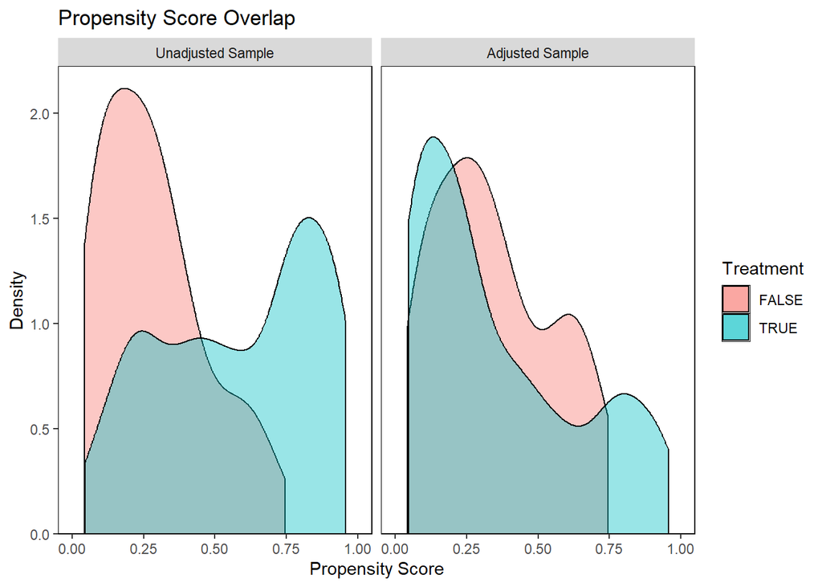

```r
bal.plot(ATE.unstab, which = "both")+
  labs(title="Propensity Score Overlap") +
  xlim(c(0,1)) +
  labs(x = "Propensity Score", y = "Density")
```

It can be seen that the unadjusted propensity scores have some issues in the tails. After weighting the overlap seems sufficient.

### Check covariate balance after weighting

Using the weights, we can now check the covariate balance after reweighting the individuals w.r.t. to the criterion $\vert SMD\vert \le 0.1$:

```r
###balance check after weighting
bal.tab(ATE.unstab, un=T,thresholds = c(m = .1))
```

```
## Balance Measures
##                 Type Diff.Un Diff.Adj    M.Threshold
## prop.score  Distance  1.2795   0.0676 Balanced, <0.1
## age          Contin. -0.9662  -0.0337 Balanced, <0.1
## gender_Male   Binary  0.3267   0.0086 Balanced, <0.1
##
## Balance tally for mean differences
##                    count
## Balanced, <0.1         3
## Not Balanced, >0.1     0
##
## Variable with the greatest mean difference
##  Variable Diff.Adj    M.Threshold
##       age  -0.0337 Balanced, <0.1
##
## Effective sample sizes
##             FALSE   TRUE
## Unadjusted 300.   200.
## Adjusted   263.41  89.32
```

Before weigthing, age and gender are unbalanced $\vert SMD\vert > 0.1$. Using unstabilized weights, the covariates are balanced w.r.t. SMD criterion. Effective sample size is decrease from $N=500$ to $ESS=263.41+89.32=352.73 (70.5%)$. Thus, we see a ~30% decrease in precision.

### Weighted analysis

Now we are ready to run the weighted analysis (including robust variance estimation).

```r
###Weighted binomial regression using robust variance estimation
IPTW <-glm_weightit(y ~ (trt=="B"), data = data.IPTW, family = binomial, weights = ATE.unstab$weights,vcov="HC0")

###compute confidence intervals
ci.IPTW<-confint(IPTW)
```

The adjusted estimate of the log odds ratio of treatment $B$ vs. $C$ after weighting is 0.73 (95% CI: 0.17-1.28)

### Graphically summarizing results

In order to get a visual overview, we jointly plot the results of all analyses. The true treatment effect (used for the data generating process) was $\beta_{BC}=0.9$

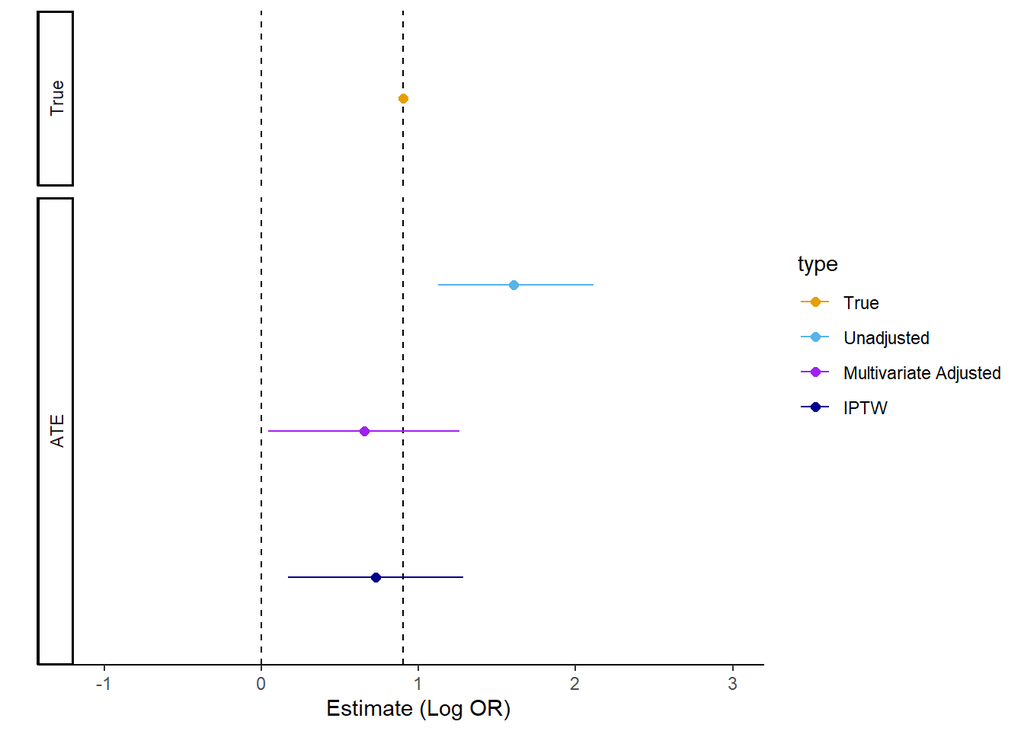

```r
# Forest plot of results
plotdat <- data_frame(
  #identifier for analysis type
  id = 1:4,
  #Estimand
  Comparison = factor(c(1, 2,2,2),labels = c("True", "ATE")),
  #Estimate
  Estimate = c(0.9,uni.log$coefficients[2],multi.log$coefficients[2],IPTW$coefficients[2]),
  #Lower CI
  lo = c(NA,ci.uni.log[2,1],ci.multi.log[2,1],ci.IPTW[2,1]),
  #Upper CI
  hi = c(NA,ci.uni.log[2,2],ci.multi.log[2,2],ci.IPTW[2,2]),
  #Type of analysis
  type = factor(c(1,2,3,4),labels=c("True", "Unadjusted", "Multivariate Adjusted", "IPTW"))
  )

#Plot
ggplot(aes(x = Estimate, y = id, col = type), data = plotdat) +
  geom_vline(xintercept = c(0,0.9), lty = 2) +
  geom_point(size = 2) +
  geom_segment(aes(y = id, yend = id, x = lo, xend = hi), na.rm = TRUE) +
  xlab("Estimate (Log OR)") +
  xlim(c(-1,3))+
  facet_grid(Comparison~., switch = "y", scales = "free_y", space = "free_y") +
  scale_y_reverse(name = "", breaks = NULL, expand = c(0, 0.6))+
  scale_color_manual(values=c( "#E69F00", "#56B4E9","purple","darkblue"))+
  theme_classic()
```

A naive comparison, ignoring the presence of confounding factors, would lead to a biased estimate of $\beta_{BC}$. In particular, the corresponding confidence intervals exclude the true effect. In contrast, the estimate from the multivariate analyses as well as the weighted analyses are much closer to the true value, and their confidence intervals include the true value.

## (Anchored) Matching adjusted indirect comparison

The following implementation (and details on calculation) is based on the following report:

Phillippo, D.M., Ades, A.E., Dias, S., Palmer, S., Abrams, K.R., Welton, N.J. NICE DSU Technical Support Document 18:  
Methods for population-adjusted indirect comparisons in submission to NICE. 2016. Available from [http://www.nicedsu.org.uk](https://www.sheffield.ac.uk/nice-dsu/tsds/population-adjusted)

We provide a worked example of an anchored form of MAIC in a simple two-study scenario ($BA$ IPD and $CA$ aggregate study). As above, we include only two covariates, age and gender, and age will act as an effect modifier.

First, we load the dataset `MAIC_anchored.csv`, which includes all data for the $BA$ trial:

```r
data.MAIC <- read.csv("MAIC_anchored.csv")
```

The data looks as follows:

```r
print(data.MAIC[1:6,],row.names=F)
```

```
##  X ID age gender trt y trtn
##  1  1  29   Male   A 1    0
##  2  2  22 Female   A 1    0
##  3  3  26   Male   A 1    0
##  4  4  55   Male   A 1    0
##  5  5  27 Female   A 1    0
##  6  6  22   Male   A 0    0
```

| Parameter name | Description |
| --- | --- |
| *ID* | unique subject identifier |
| *age* | age (continuous) |
| *gender* | Sex (female or male) |
| *trt* | Treatment assignment ($B$ or $A$) |
| *y* | Event indicator (1: yes, 0: no) |

```r
# Tabulate (via dplyr methods)
data.MAIC %>% group_by(trt) %>%
  summarise(n(), mean(age), sd(age), `n(male)`=sum(gender=="Male"),
            `%(male)`=mean(gender=="Male"), sum(y), mean(y))
```

```
## # A tibble: 2 × 8
##   trt   `n()` `mean(age)` `sd(age)` `n(male)` `%(male)` `sum(y)` `mean(y)`
##   <chr> <int>       <dbl>     <dbl>     <int>     <dbl>    <int>     <dbl>
## 1 A       200        45.1      16.1       137     0.685      162      0.81
## 2 B       200        43.0      15.3       144     0.72        66      0.33
```

Second,we will create a dataset including the aggregated data tabulated on the course’s slide:

```r
AC.AgD<-data.frame(age.mean=54.8,
                   age.sd=8.5,
                   N.male=232,
                   prop.male=38.6,
                   y.A.sum=277,
                   y.A.bar=0.923,
                   N.A=300,
                   y.C.sum=27,
                   y.C.bar=0.09,
                   N.C=300)
```

The naive comparison, ignoring the presence of effect modifiers, would calculate the $B$ vs. $C$ effect using the standard odds ratio formulae. Finally we construct the indirect comparison estimate $\hat \beta_{BC}$ on the log odds ratio scale, using the fact that $d_{BC}=d_{BA}-d_{CA}$

```r
# Manually calculate (log) odds ratio in BA trial
data.MAIC %>% group_by(trt) %>%
summarise(y.sum = sum(y)) %>%
spread(trt, y.sum) %>%
  with({
    d.AB.AB <<- log(B * (400/2 - A) / (A * (400/2 - B)))
    var.d.AB.AB <<- 1/B + 1/(400/2 - A) + 1/A + 1/(400/2 - B)
  })

# Manually calculate (log) odds ratio in BA trial
d.AC <- with(AC.AgD, log(y.C.sum * (N.A - y.A.sum) / (y.A.sum * (N.C - y.C.sum))))
var.d.AC <- with(AC.AgD, 1/y.A.sum + 1/(N.A - y.A.sum) + 1/y.C.sum + 1/(N.C - y.C.sum))

### log(OR) for BC comparison (Bucher's approach)
BC_Bucher<-d.AB.AB - d.AC
LCL.log.OR.BC<-BC_Bucher-qnorm(0.975)*sqrt(var.d.AB.AB + var.d.AC)
UCL.log.OR.BC<-BC_Bucher+qnorm(0.975)*sqrt(var.d.AB.AB + var.d.AC)
```

The unadjusted estimate of the log odds ratio of treatment $B$ vs. $C$ according to Bucher’s approach is 2.64 (95% CI: 1.9-3.38). The trial log odds ratios are $log(OR_{BA})$=-2.16 and $log(OR_{CA})$=-4.8, respectively.

Alternatively, we can compute the (log) odds ratio of the $BA$ trial via the respective binomial regression models:

```r
#univariate binomial regression BA trial
glm(y ~ (trt=="B") , data = data.MAIC, family = binomial)
```

```
##
## Call:  glm(formula = y ~ (trt == "B"), family = binomial, data = data.MAIC)
##
## Coefficients:
##    (Intercept)  trt == "B"TRUE
##          1.450          -2.158
##
## Degrees of Freedom: 399 Total (i.e. Null);  398 Residual
## Null Deviance:       546.7
## Residual Deviance: 448.2     AIC: 452.2
```

## Matching according to inclusion criteria of CA trial

According the inclusion criteria of the $CA$ trial, we restrict the IPD of the $BA$ trial to the age between 40 and 70 years (inclusive):

```r
#Exclude IPD which does not fit I/E of AC (age>70 or age <40)
AB.IPD.match<-subset(data.MAIC,age<=70 & age>=40)

#Investigate covariates
AB.IPD.match %>% group_by(trt) %>%
  summarise(n(), mean(age), sd(age), `n(male)`=sum(gender=="Male"),
            `%(male)`=mean(gender=="Male"), sum(y), mean(y))
```

```
## # A tibble: 2 × 8
##   trt   `n()` `mean(age)` `sd(age)` `n(male)` `%(male)` `sum(y)` `mean(y)`
##   <chr> <int>       <dbl>     <dbl>     <int>     <dbl>    <int>     <dbl>
## 1 A       118        56.8      8.87        77     0.653      107     0.907
## 2 B       109        54.8      9.02        83     0.761       18     0.165
```

We see that in both arms approximately 50% of individuals are withdrawn due to matching according to age $(ESS=227)$. However, the age distribution is much closer to the $CA$ trial.

We now apply Bucher’s approach to the matched $BA$ IPD, i.e. we construct the indirect comparison estimate $\hat d_{BC(CA)}$ on the log odds ratio scale (in the $CA$ population), using the fact that $d_{BC(CA)}=$d_{BA(CA)}-$d_{CA(CA)}

```r
#univariate binomial regression matched BA trial
uni.log.AB.matched <-  glm(y ~ (trt=="B") , data = AB.IPD.match, family = binomial)

### log(OR) for BC comparison
BC_Bucher.matched<-uni.log.AB.matched$coefficients[2]-d.AC
LCL.log.OR.BC.matched<-BC_Bucher.matched-qnorm(0.975)*sqrt(vcov(uni.log.AB.matched)[2,2]+var.d.AC)
UCL.log.OR.BC.matched<-BC_Bucher.matched+qnorm(0.975)*sqrt(vcov(uni.log.AB.matched)[2,2]+var.d.AC)
```

The adjusted estimate of the log odds ratio of treatment $B$ vs. $C$ according to matched Bucher’s approach is 0.91 (95% CI: -0.08-1.9).

## Weight calculation

We will now perform the MAIC. For details regarding the calculation of weights, we refer to Philippo et al. Since prognostic factors are balanced within both studies, the weight calculation will only account for the effect modifier *age*.

```r
# Objective function
objfn <- function(a1, X){
  sum(exp(X %*% a1))
}

# Gradient function
gradfn <- function(a1, X){
  colSums(sweep(X, 1, exp(X %*% a1), "*"))
}

# Centred EMs
X.EM.0 <- sweep(with(AB.IPD.match, cbind(age, age^2)), 2,
                with(AC.AgD, c(age.mean, age.mean^2 + age.sd^2)), '-')

# Estimate weights
opt1 <- optim(par = c(0,0), fn = objfn, gr = gradfn, X = X.EM.0, method = "BFGS")
a1 <- opt1$par

wt <- exp(X.EM.0 %*% a1)
```

The approximate effective sample size is calcualted as

```r
# ESS
sum(wt)^2/sum(wt^2)
```

```
## [1] 221.2693
```

Compared to the matched scenario, this is only a very small additional reduction. This is not surprising, as the age distribution in the matched $BA$ trial is very close to the the $CA$ trial.

### Weighted analysis

Now we are ready to run the weighted analysis. The `sandwich` package will calculate standard errors using a sandwich estimator. The stimated relative effect $\hat d_{BA(CA)}$ of $B$ vs. $A$. in the $CA$ population is found by taking weigthed means of the outcomes in the $BA$ trial. However, in practice it is easier to generate these estimates using a simple linear model.

```r
###Weighted binomial regression using robust variance estimation on BA trial
fit.AB.MAIC <-glm_weightit(y ~ (trt=="B"), data = AB.IPD.match, family = binomial, weights = wt,vcov="HC0")

### log(OR) for BC comparison in the CA trial
d.AB.MAIC<-fit.AB.MAIC$coefficients[2]-d.AC
LCL.log.OR.BC.MAIC<-d.AB.MAIC-qnorm(0.975)*sqrt(vcov(fit.AB.MAIC)[2,2]+var.d.AC)
UCL.log.OR.BC.MAIC<-d.AB.MAIC+qnorm(0.975)*sqrt(vcov(fit.AB.MAIC)[2,2]+var.d.AC)
```

So the MAIC estimate of the log odds ratio of treatment $B$ vs. $C$ is 1.03 (95% CI: 0.07-1.98).

The balance check of covariates is as follows:

```r
# Check balance
AB.IPD.match  %>% mutate(wt)  %>%
  summarise(age.mean = weighted.mean(age, wt),
            age.sd = sqrt(sum(wt / sum(wt) * (age - age.mean)^2)),
            `n(male)`=sum(1*(gender=="Male")*wt),
            `%(male)`=mean(1*(gender=="Male")*wt))
```

```
##   age.mean  age.sd  n(male)   %(male)
## 1     54.8 8.49998 156.6884 0.6902572
```

Note that - per definition of weight calculation - the mean age (and its standard deviation) of the matched and weighted $BA$ sample coincides with the respective numbers of the $CA$ trial.

### Graphically summarizing results

In order to get a visual overview, we jointly plot the results of all analyses. The true treatment effect (used for the data generating process) was $\beta_{BC}=0.9$

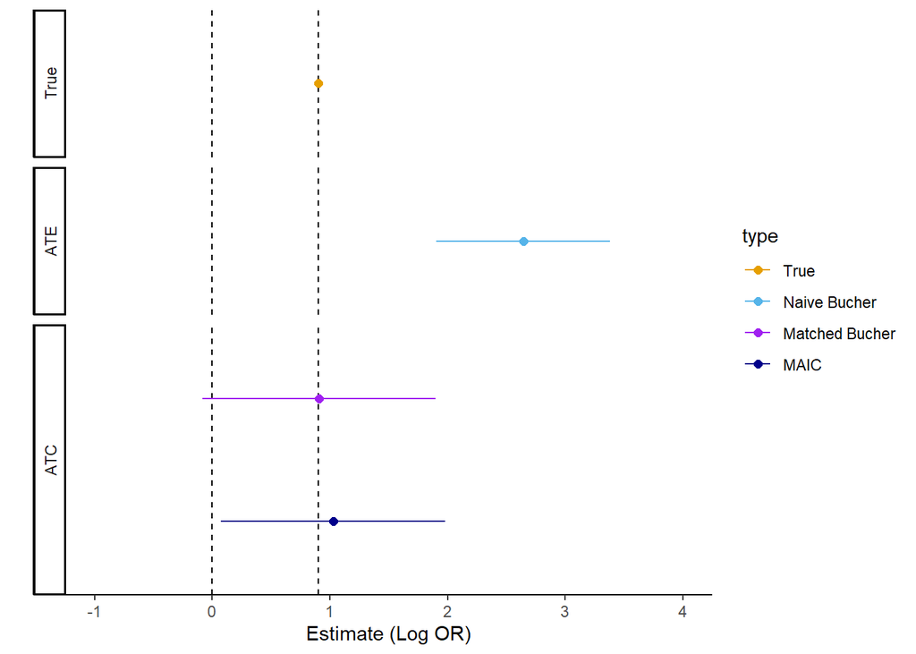

```r
# Forest plot of results
plotdat <- data_frame(
  #identifier for analysis type
  id = 1:4,
  #Estimand
  Comparison = factor(c(1, 2,3,3),labels = c("True","ATE", "ATC")),
  #Estimate
  Estimate = c(0.9,BC_Bucher,BC_Bucher.matched,d.AB.MAIC),
  #Lower CI
  lo = c(NA,LCL.log.OR.BC,LCL.log.OR.BC.matched,LCL.log.OR.BC.MAIC),
  #Upper CI
  hi = c(NA,UCL.log.OR.BC,UCL.log.OR.BC.matched,UCL.log.OR.BC.MAIC),
  #Type of analysis
  type = factor(c(1,2,3,4),labels=c("True", "Naive Bucher", "Matched Bucher", "MAIC"))
  )

#Plot
ggplot(aes(x = Estimate, y = id, col = type), data = plotdat) +
  geom_vline(xintercept = c(0,0.9), lty = 2) +
  geom_point(size = 2) +
  geom_segment(aes(y = id, yend = id, x = lo, xend = hi), na.rm = TRUE) +
  xlab("Estimate (Log OR)") +
  xlim(c(-1,4))+
  facet_grid(Comparison~., switch = "y", scales = "free_y", space = "free_y") +
  scale_y_reverse(name = "", breaks = NULL, expand = c(0, 0.6))+
  scale_color_manual(values=c( "#E69F00", "#56B4E9","purple","darkblue"))+
  theme_classic()
```

A naive comparison, ignoring the presence of confounding factors, would lead to a biased estimate of $\beta_{BC}$. In particular, the corresponding confidence intervals exclude the true effect. In contrast, the estimates $_{BC(CA)}.from the Bucher comparison after matching as well as the weighted analyses are much closer to the true value, and their confidence intervals include the true value. The MAIC also detects a significant effect of treatment $B$ vs. $C$ compared to the matched Bucher analysis. It has to be noted that the estimand changed from ATE to ATC when considering matched Bucher as well as MAIC.

## Disclaimer

Correctness of implementation cannot be guaranteed. It should be used for learning purposes only.